# Introduction

This insurance dataset contains some information on insurance customers, such as age, BMI, region and their insurance charges. I am tasked with exploring these characteristics about the customers and identify the factors that contribute to their insurance charges. I will demonstrate my explotaratory data analysis skills by asking the following questions about this insurance dataset:

# Goals for the project:

1. Find the average age of the patients, average insurance charge and average BMI.
2. Where are majority of the individuals from?
3. How does smoking, age, BMI and sex affect insurance charges?
4. What is the average insurance cost for people with at least one child?
5. Who pays more in insurance charges, males or females?
6. What is the relationship between BMI and insurance charges.(Finding the correlation between the two)
7. What is the relationship between smoking status and insurance charges(find the association between the two

# Exploratory Data Analysis:

```python
#Importing relevant libariries
    import scipy.stats
    import pandas as pd
    import numpy as np
    import matplotlib.pyplot as plt
    import statsmodels.api as sm
    import seaborn as sns
```

```python
#Load csv file into a dataframe
    insurance = pd.read_csv('insurance.csv')

    #Let's look at the first few rows
    insurance.head()
    #So in this dataset, we have age, sex, bmi, children, smoker, region and charges as our variables/columns.
    #These columns are pretty straightforward.
    #So, I will not waste time into explaining what these columns mean.
```

|  | index | age | sex | bmi | children | smoker | region | charges |
| --- | --- | --- | --- | --- | --- | --- | --- | --- |
| 0 | 0 | 19 | female | 27.900 | 0 | yes | southwest | 16884.92400 |
| 1 | 1 | 18 | male | 33.770 | 1 | no | southeast | 1725.55230 |
| 2 | 2 | 28 | male | 33.000 | 3 | no | southeast | 4449.46200 |
| 3 | 3 | 33 | male | 22.705 | 0 | no | northwest | 21984.47061 |
| 4 | 4 | 32 | male | 28.880 | 0 | no | northwest | 3866.85520 |

```python
#Okay, let us look at how many null values, missing data, and data types of each column in our dataset.
    insurance.info()
```

```
<class 'pandas.core.frame.DataFrame'>
    RangeIndex: 1338 entries, 0 to 1337
    Data columns (total 8 columns):
     #   Column    Non-Null Count  Dtype
    ---  ------    --------------  -----
     0   index     1338 non-null   int64
     1   age       1338 non-null   int64
     2   sex       1338 non-null   object
     3   bmi       1338 non-null   float64
     4   children  1338 non-null   int64
     5   smoker    1338 non-null   object
     6   region    1338 non-null   object
     7   charges   1338 non-null   float64
    dtypes: float64(2), int64(3), object(3)
    memory usage: 68.0+ KB
```

```python
#So, we can see that we have 8 columns and 1338 rows of data. At first glance, we have no missing values in our dataset
    #Also, the datatypes for each column is correct.

    #Let's see if there are really any rows in our dataset with NaN as the entry, meaning there is missing data
    np.where(pd.isnull(insurance)) #if the result is a empty array, then there is no missing data.
```

```
(array([], dtype=int32), array([], dtype=int32))
```

```python
#So we have no rows with Nan as the entry.
    #Let's count the number of missing values in each column
    insurance.isna().sum()
```

```
index       0
    age         0
    sex         0
    bmi         0
    children    0
    smoker      0
    region      0
    charges     0
    dtype: int64
```

# Okay, so each column the sum is zero, so there are no missing values. Great, this dataset is fairly clean.

```python
#To answer our first question, what is the average age of the patients?
    average_age = insurance['age'].mean()
    print('The average age is' + ' ' + str(average_age))
```

```
The average age is 39.20702541106129
```

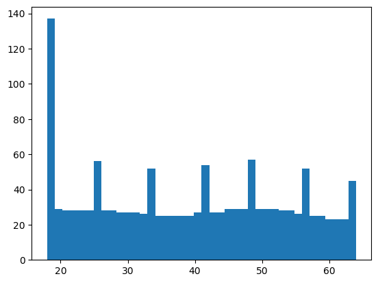

```python
#So, the average age is 39 years old.
    #I want to see the distribution of the ages of the people in our dataset to get an idea of the variability.
    plt.hist(insurance.age, bins=40)
    plt.show()
```

```python
#It was appropriate to use mean to find the average age in our dataset because the distribution for age is not skewed.
    #Examining the distribution, we see a spike just before age 20.
    #So let's quickly calculate the mode.
    mode_age = insurance.age.mode()
    mode_age
    #Here we see that we have mostly 18 year olds in the dataset. However, the average age is 39 years.
```

```
0    18
    Name: age, dtype: int64
```

```python
#Let's find out what is the average BMI for the people in our dataset.
    avg_bmi = insurance.bmi.mean()
    print('The average BMI in our dataset is' + ' ' + str(avg_bmi))
    #The average BMI is 30.66.
```

```
The average BMI in our dataset is 30.663396860986538
```

```python
#Let's find out the average insurance charge in our dataset
    avg_charge = insurance.charges.mean()
    avg_charge
    #The average insurance charge is 13,270.
```

```
13270.422265141257
```